# White Wine Analysis by Peter Predtechensky

While looking at the raw data in Excel I noticed that there are quite many completely identical observations.

# Univariate Plots Section

GUIDING QUESTION: Which chemical properties influence the quality of white wines?

# Univariate Analysis

```
##  [1] "id"                   "fixed.acidity"        "volatile.acidity"
##  [4] "citric.acid"          "residual.sugar"       "chlorides"
##  [7] "free.sulfur.dioxide"  "total.sulfur.dioxide" "density"
## [10] "pH"                   "sulphates"            "alcohol"
## [13] "quality"
```

```
## [1] 4898   13
```

```
## 'data.frame':    4898 obs. of  13 variables:
##  $ id                  : int  1 2 3 4 5 6 7 8 9 10 ...
##  $ fixed.acidity       : num  7 6.3 8.1 7.2 7.2 8.1 6.2 7 6.3 8.1 ...
##  $ volatile.acidity    : num  0.27 0.3 0.28 0.23 0.23 0.28 0.32 0.27 0.3 0.22 ...
##  $ citric.acid         : num  0.36 0.34 0.4 0.32 0.32 0.4 0.16 0.36 0.34 0.43 ...
##  $ residual.sugar      : num  20.7 1.6 6.9 8.5 8.5 6.9 7 20.7 1.6 1.5 ...
##  $ chlorides           : num  0.045 0.049 0.05 0.058 0.058 0.05 0.045 0.045 0.049 0.044 ...
##  $ free.sulfur.dioxide : num  45 14 30 47 47 30 30 45 14 28 ...
##  $ total.sulfur.dioxide: num  170 132 97 186 186 97 136 170 132 129 ...
##  $ density             : num  1.001 0.994 0.995 0.996 0.996 ...
##  $ pH                  : num  3 3.3 3.26 3.19 3.19 3.26 3.18 3 3.3 3.22 ...
##  $ sulphates           : num  0.45 0.49 0.44 0.4 0.4 0.44 0.47 0.45 0.49 0.45 ...
##  $ alcohol             : num  8.8 9.5 10.1 9.9 9.9 10.1 9.6 8.8 9.5 11 ...
##  $ quality             : int  6 6 6 6 6 6 6 6 6 6 ...
```

```
##        id       fixed.acidity    volatile.acidity  citric.acid
##  Min.   :   1   Min.   : 3.800   Min.   :0.0800   Min.   :0.0000
##  1st Qu.:1225   1st Qu.: 6.300   1st Qu.:0.2100   1st Qu.:0.2700
##  Median :2450   Median : 6.800   Median :0.2600   Median :0.3200
##  Mean   :2450   Mean   : 6.855   Mean   :0.2782   Mean   :0.3342
##  3rd Qu.:3674   3rd Qu.: 7.300   3rd Qu.:0.3200   3rd Qu.:0.3900
##  Max.   :4898   Max.   :14.200   Max.   :1.1000   Max.   :1.6600
##  residual.sugar     chlorides       free.sulfur.dioxide
##  Min.   : 0.600   Min.   :0.00900   Min.   :  2.00
##  1st Qu.: 1.700   1st Qu.:0.03600   1st Qu.: 23.00
##  Median : 5.200   Median :0.04300   Median : 34.00
##  Mean   : 6.391   Mean   :0.04577   Mean   : 35.31
##  3rd Qu.: 9.900   3rd Qu.:0.05000   3rd Qu.: 46.00
##  Max.   :65.800   Max.   :0.34600   Max.   :289.00
##  total.sulfur.dioxide    density             pH          sulphates
##  Min.   :  9.0        Min.   :0.9871   Min.   :2.720   Min.   :0.2200
##  1st Qu.:108.0        1st Qu.:0.9917   1st Qu.:3.090   1st Qu.:0.4100
##  Median :134.0        Median :0.9937   Median :3.180   Median :0.4700
##  Mean   :138.4        Mean   :0.9940   Mean   :3.188   Mean   :0.4898
##  3rd Qu.:167.0        3rd Qu.:0.9961   3rd Qu.:3.280   3rd Qu.:0.5500
##  Max.   :440.0        Max.   :1.0390   Max.   :3.820   Max.   :1.0800
##     alcohol         quality
##  Min.   : 8.00   Min.   :3.000
##  1st Qu.: 9.50   1st Qu.:5.000
##  Median :10.40   Median :6.000
##  Mean   :10.51   Mean   :5.878
##  3rd Qu.:11.40   3rd Qu.:6.000
##  Max.   :14.20   Max.   :9.000
```

### What is the structure of your dataset?

The White Wine Quality dataset consists of 13 variables and 4898 observations. The first variable is an “id” of wines, so it will be used only for references.

### What is/are the main feature(s) of interest in your dataset?

My main feature of interest is the wine quality. I will investigate how different chemical (and not only) wine parameters affect the wine quality.

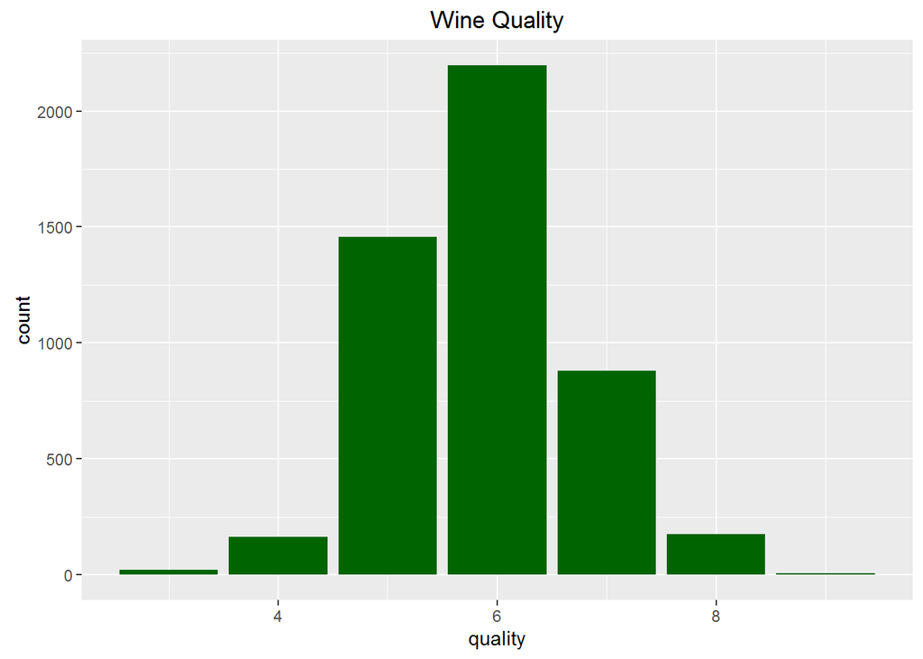

I see that the most popular quality mark is 6. More than 2000 wine types are of this quality. I also see that the minimal quality is 3 and the best quality is 9. The quality distribution appears to be close to normal.

### What other features in the dataset do you think will help support your investigation into your feature(s) of interest?

As I saw from above, there are the following chemical and physical parameters-variables that I want to investigate further:

1. Fixed acidity;
2. Volatile acidity;
3. Citric acid;
4. Residual sugar;
5. Chlorides;
6. Free sulfur dioxide;
7. Total sulfur dioxide;
8. Density;
9. pH;
10. Sulphates;
11. Alcohol.

Let’s take a more closer look at all of them one by one:

#### *Fixed Acidity*

```
##    Min. 1st Qu.  Median    Mean 3rd Qu.    Max.
##   3.800   6.300   6.800   6.855   7.300  14.200
```

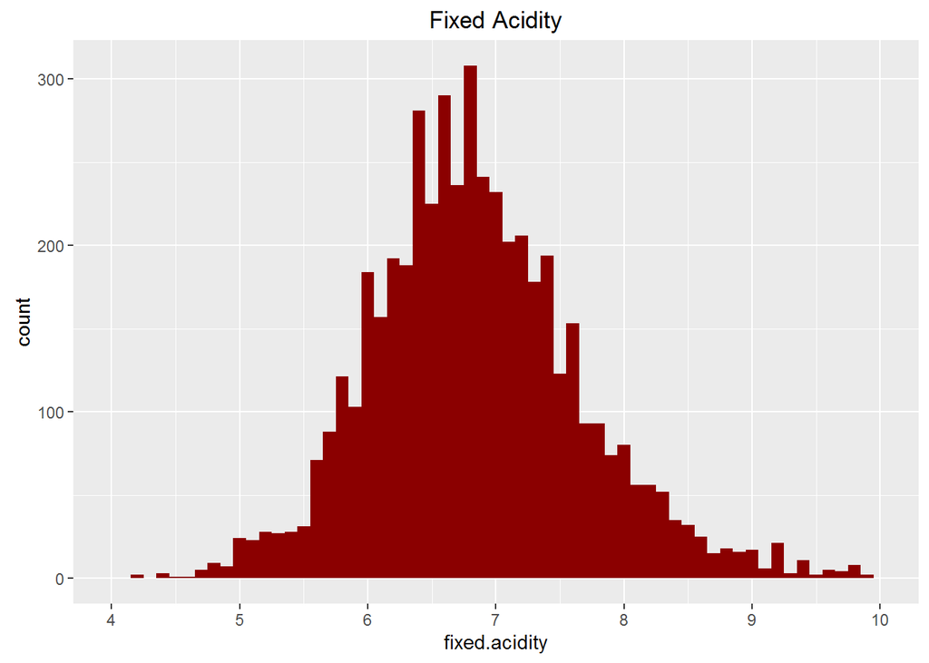

Fixed acidity seems to be normally distributed. 50% of values fall between 6.3 and 7.3. The mean fixed acidity value is 6.8. There are a few outliers: approx. at 12 and at 14.2, which I removed from the plot by scaling.

#### *Volatile Acidity*

```
##    Min. 1st Qu.  Median    Mean 3rd Qu.    Max.
##  0.0800  0.2100  0.2600  0.2782  0.3200  1.1000
```

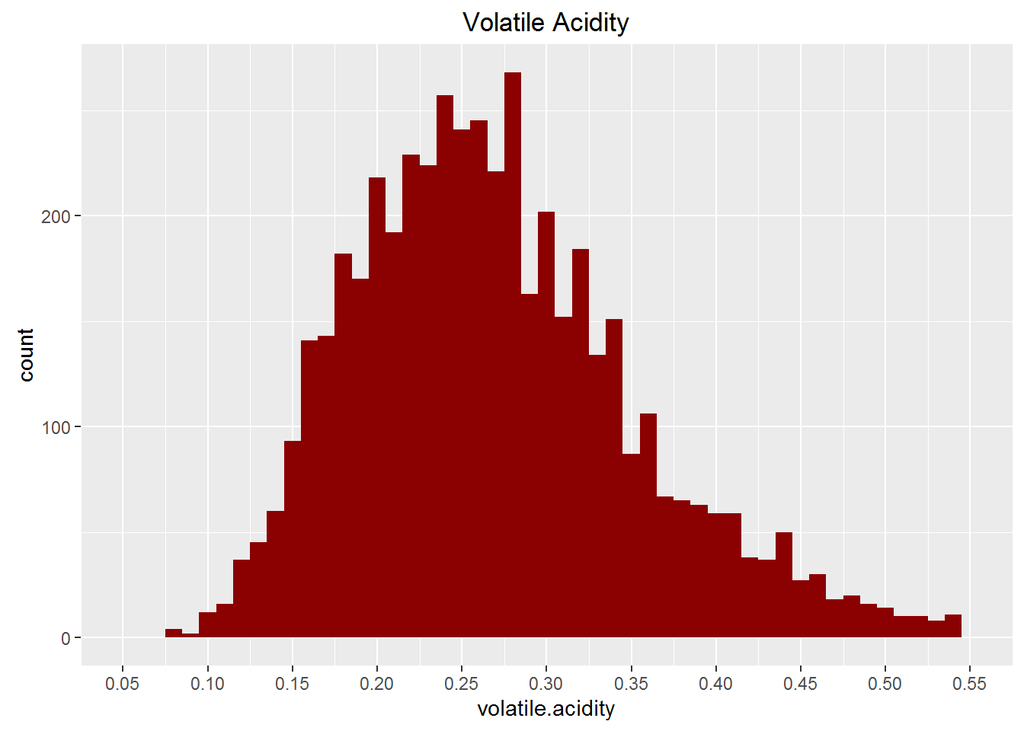

Volatile acidity seems to be also normally distributed. Most values fall between 0.15 and 0.35. The mean fixed acidity value is 0.278. There are a few outliers. For instance, the max value of 1.1. I removed the outliers from the plot by scaling.

#### *Citric Acid*

```
##    Min. 1st Qu.  Median    Mean 3rd Qu.    Max.
##  0.0000  0.2700  0.3200  0.3342  0.3900  1.6600
```

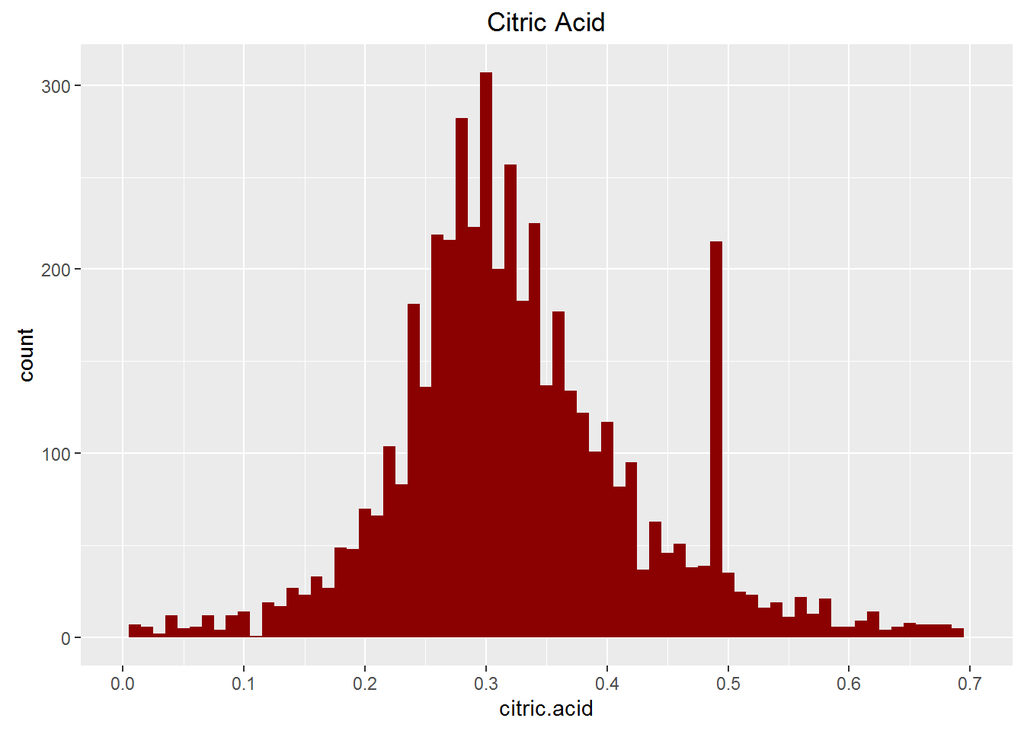

Citric acid seems to be also normally distributed. Most values fall between 0.25 and 0.35. The mean fixed acidity bin is at 0.334. There are a few outliers: approx. at 1.2, at 1.66 (max value). I removed the outliers from the plot by scaling. Interesting peaks at 0.49 and 0.74.

#### *Residual Sugar*

```
##    Min. 1st Qu.  Median    Mean 3rd Qu.    Max.
##   0.600   1.700   5.200   6.391   9.900  65.800
```

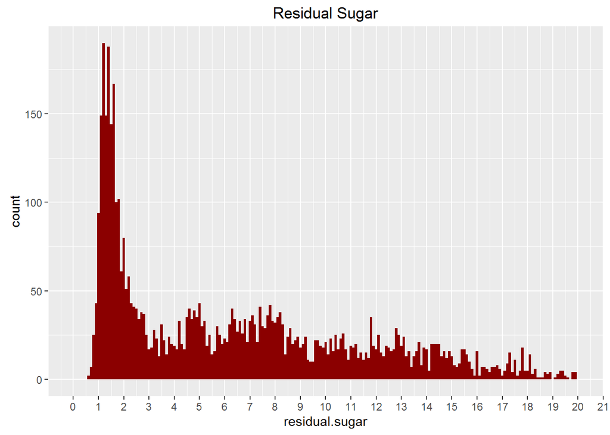

Residual sugar seems to be positively skewed. A lot of wine types - approx. 1750 - have a very low residual.sugar value. It seems that most of the wine is either dry or semi-dry. I will investigate this interesting question later. The mean value is 6.39; There are a few outliers. For instance, the max value of 65.8. I removed the outliers from the plot by scaling.

Let’s look at the plot using the scale_x_log10() method:

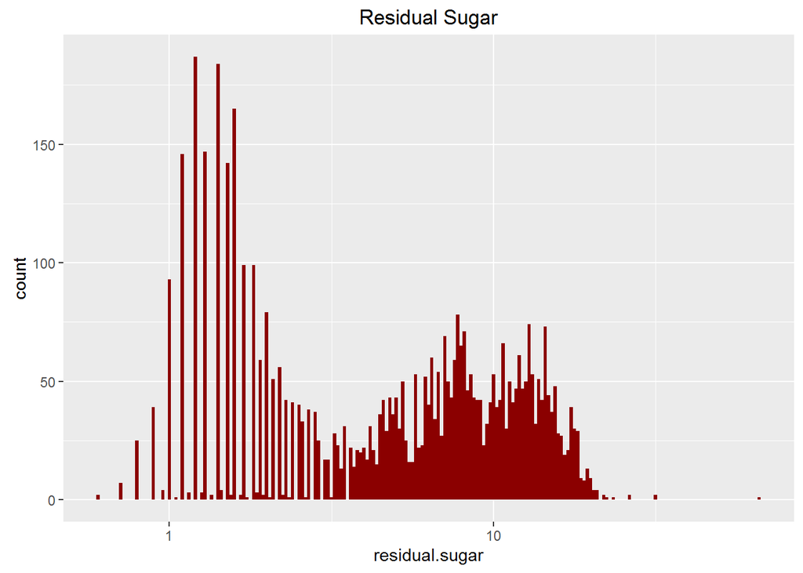

What a lovely multi-modal distribution! I feel that most of wine is semi-dry, but again: I will get back to it in more details later on.

#### *Chlorides*

```
##    Min. 1st Qu.  Median    Mean 3rd Qu.    Max.
## 0.00900 0.03600 0.04300 0.04577 0.05000 0.34600
```

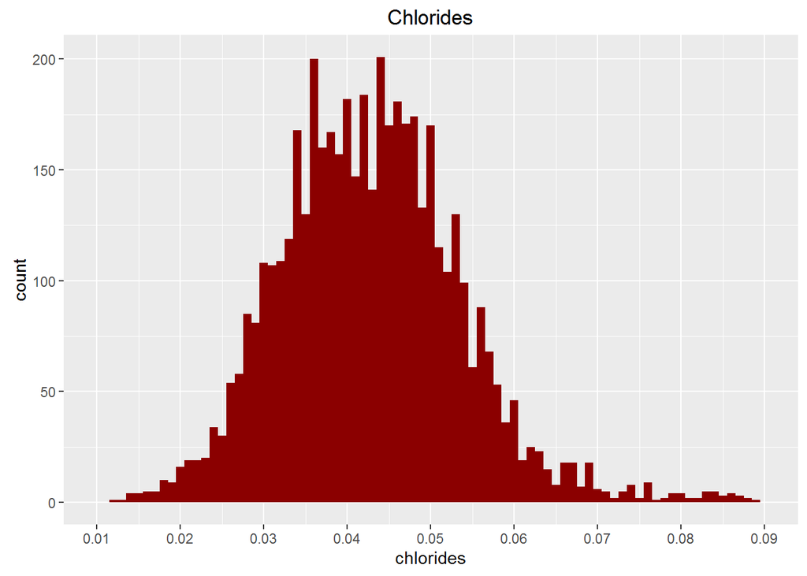

Chlorides seem to be also normally distributed. Most values fall between 0.03 and 0.055. The mean value is at 0.0458; There are a lot of outliers, such as the max value of 0.346. I removed the outliers from the plot by scaling.

#### *Free Sulfur Dioxide*

```
##    Min. 1st Qu.  Median    Mean 3rd Qu.    Max.
##    2.00   23.00   34.00   35.31   46.00  289.00
```

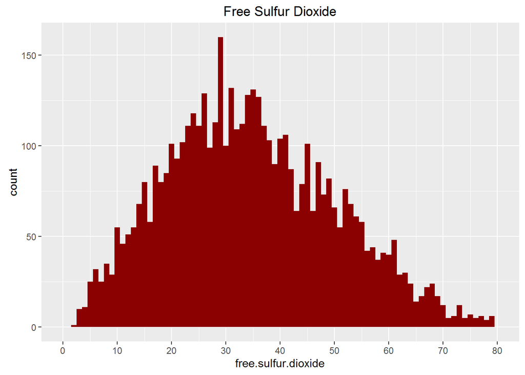

Free sulfur dioxides seem to be also normally distributed. The mean value is 35.3; Some minor outliers can be seen and a considerable outlier at 289 (max value). I removed the outliers from the plot by scaling.

#### *Total Sulfur Dioxide*

```
##    Min. 1st Qu.  Median    Mean 3rd Qu.    Max.
##     9.0   108.0   134.0   138.4   167.0   440.0
```

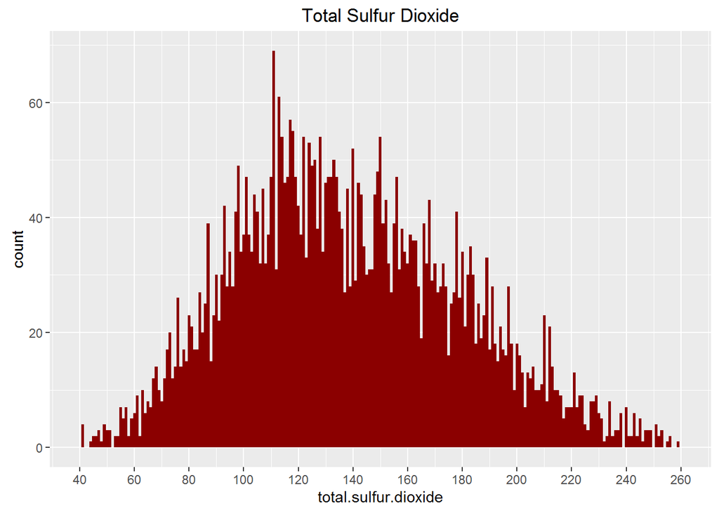

Total sulfur dioxides seem to be… well, I tend to see a bimodal distribution. Subject for discussions, probably. The mean value is 138. Some outliers. Max value of 440. I removed the outliers from the plot by scaling.

#### *Density*

```
##    Min. 1st Qu.  Median    Mean 3rd Qu.    Max.
##  0.9871  0.9917  0.9937  0.9940  0.9961  1.0390
```

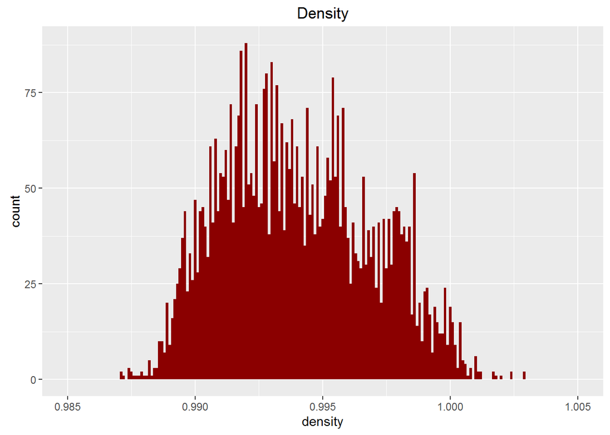

Density seems to be bimodally distributed. Subject for discussions again. Really not sure. A couple of outliers: approx. at 1.01 and 1.04 (max value). I removed the outliers from the plot by scaling.

#### *pH*

```
##    Min. 1st Qu.  Median    Mean 3rd Qu.    Max.
##   2.720   3.090   3.180   3.188   3.280   3.820
```

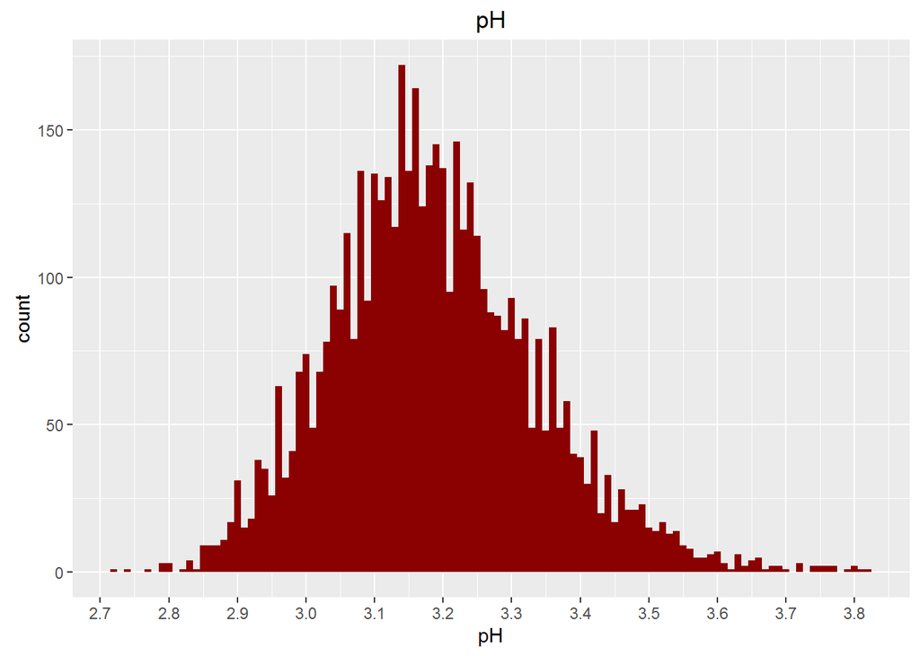

Very nice normal distribution for pH!

#### *Suplhates*

```
##    Min. 1st Qu.  Median    Mean 3rd Qu.    Max.
##  0.2200  0.4100  0.4700  0.4898  0.5500  1.0800
```

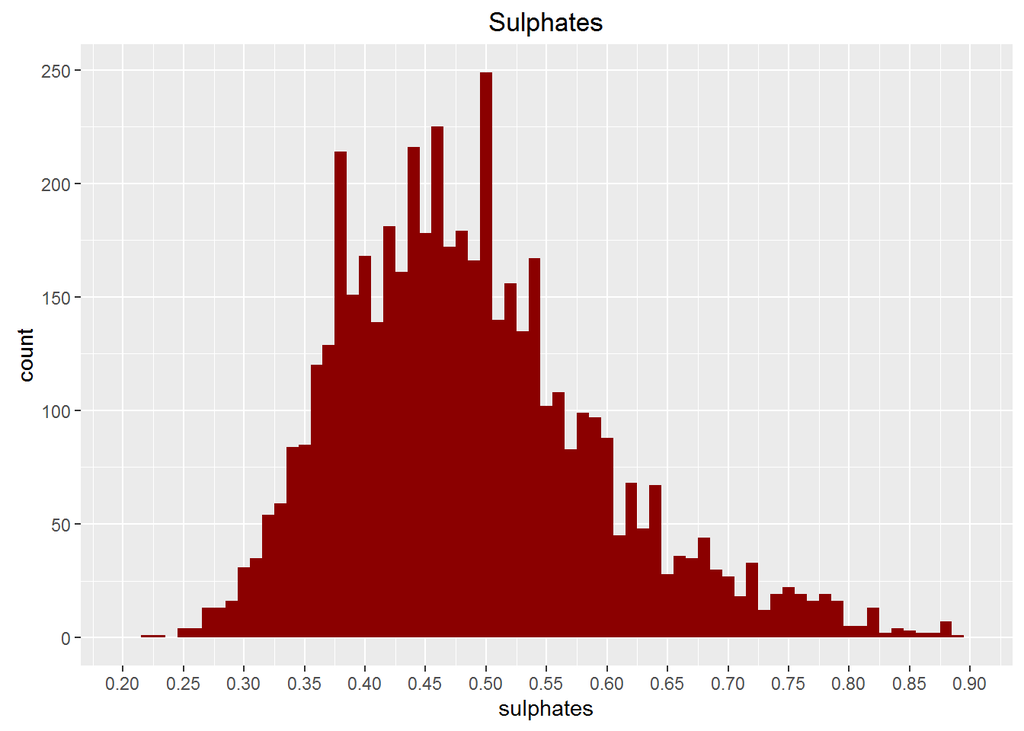

Sulphates appear to be normally distributed as well. I removed some outliers from the plot by scaling.

#### *Alcohol*

```
##    Min. 1st Qu.  Median    Mean 3rd Qu.    Max.
##    8.00    9.50   10.40   10.51   11.40   14.20
```

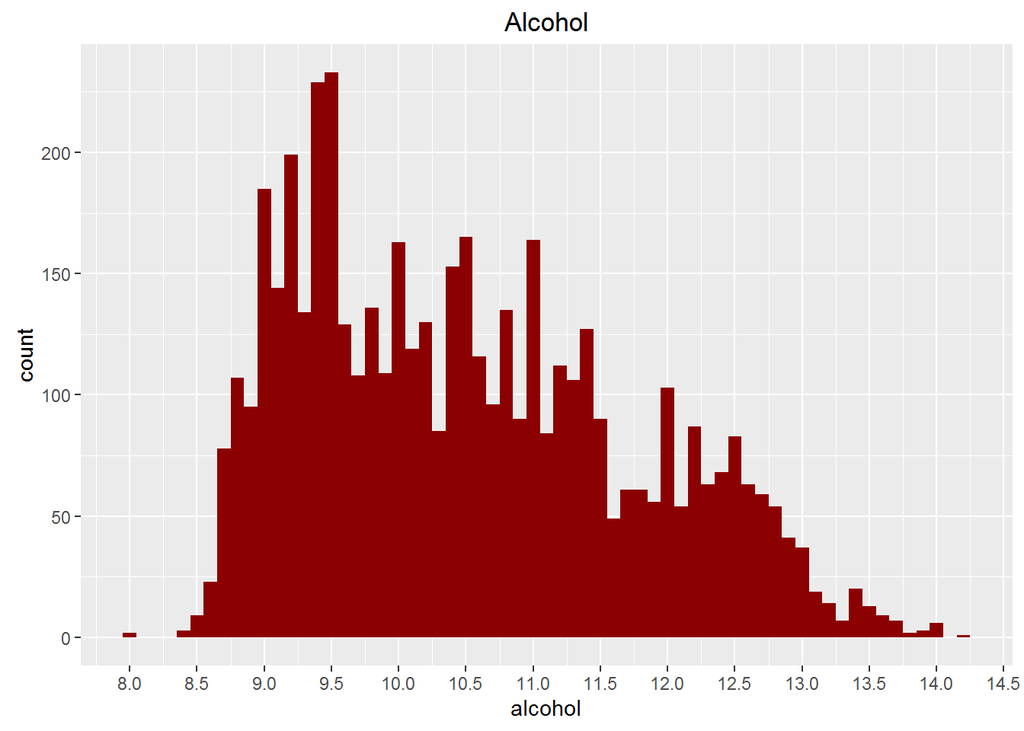

Ok, this one is the most interesting so far. Distribution is a mix of positively skewed and multi-modal. The most popular alcohol percentage is 9.4 and 9.5. However several other percentage values contain a noticeable amount of types: 9.0%, 9.2%, 10%, 10.5% and 11% at least.

### Of the features you investigated, were there any unusual distributions? Did you perform any operations on the data to tidy, adjust, or change the form of the data? If so, why did you do this?

In all cases I played with the binwidth parameter in order to make my histograms more readable and clear.

### Did you create any new variables from existing variables in the dataset?

Let me split all the wine into 3 categories: Good: quality of 8, 9; Moderate: 5, 6 and 7; Bad: 3 and 4.

I want to create a new variable named “qual” based on my criteria. Then I’ll make it a vector.

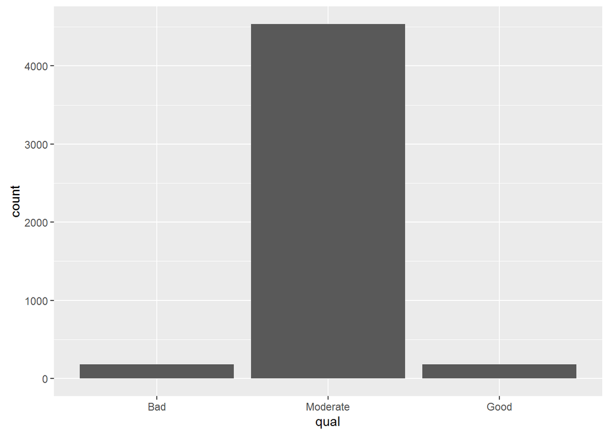

```
## [1] 183
```

```
## [1] 4535
```

```
## [1] 180
```

Based on my crireria I see the following: 1. Most of the wine is moderate: 4535 types; 2. Good wine includes 180 types; 3. Bad wine includes 183 types;

My research (wikipedia) found out the following wine classification based on residual sugar: 1. dry wine: sugar less than 4 g/dm3; 2. semi-dry: sugar 4-18; 3. semi-sweet: sugar 18-45; 4. sweet: sugar more than 45.

Let’s create another variable ‘sweetness’ and see the wine distribution based on it:

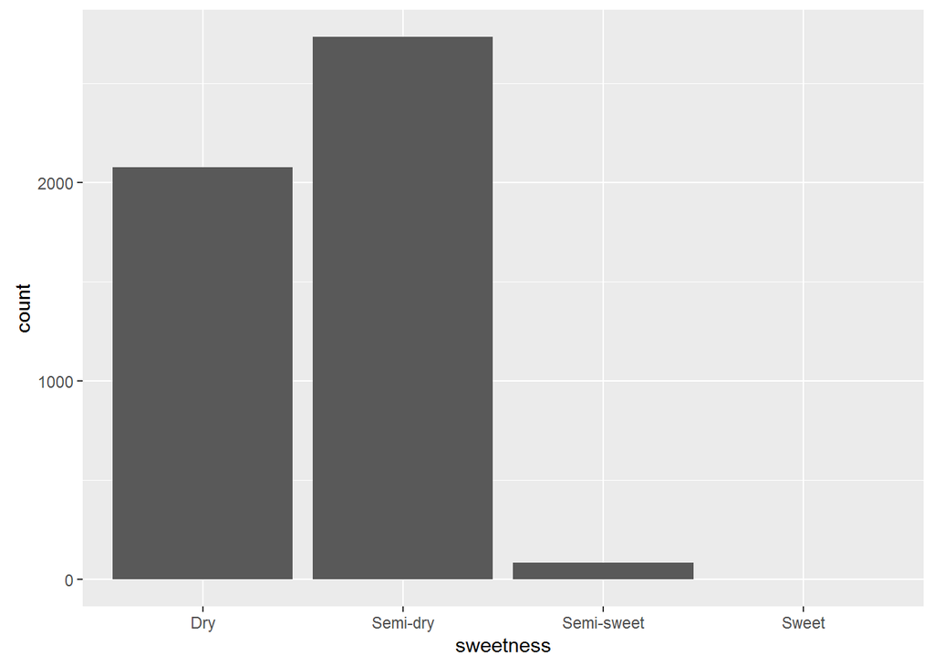

```
## [1] 2078
```

```
## [1] 2735
```

```
## [1] 84
```

```
## [1] 1
```

Ok, I see that - there is a lot of dry wine: 2078 types; - the most popular sweetness is ‘Semi-dry’: 2735 types; - ‘Semi-sweet’ wine includes 84 types; - Only 1 type is ‘Sweet’;

# Bivariate Plots Section

Let me first look at the quality distribution by sweetness:

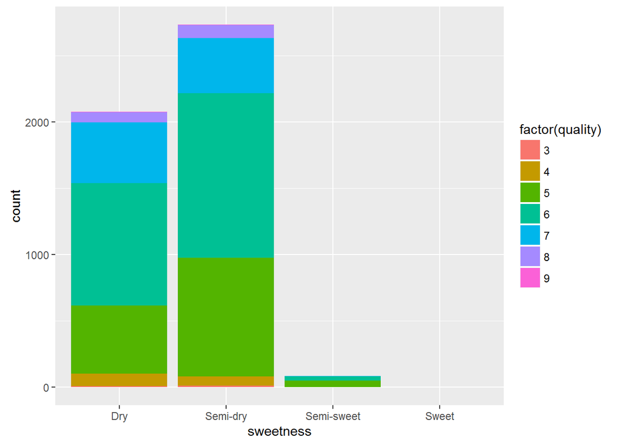

I see that best wines are either dry or semi-dry.

# Bivariate Analysis

Now let me check for relationship between different variables in my dataset. First I made a ggpairs() for all my variables except ‘id’ and manually made ones (‘qual’ and ‘sweetness’). It appeared to be badly readable, but I noticed the most important correlations from it.

Following the advice of my previous reviewer I used the corrplot and draw a representation of all correlations in my dataset. Dear reviewer, thank you very much! I appreciate your advice!

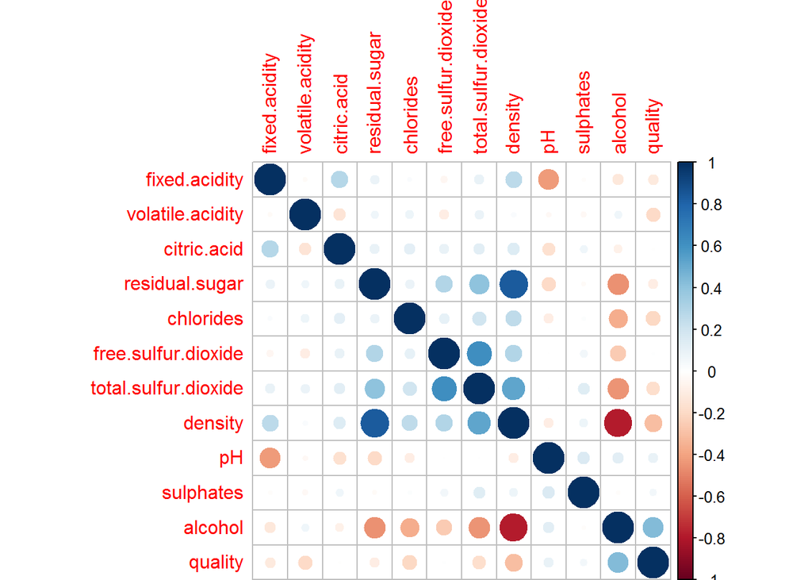

It makes very clear that we have relationship between + alcohol and density; + residual.sugar and density; + residual.sugar and alcohol; + pH and fixed.acidity; + free.sulfur.dioxide and total.sulfur.dioxide and some others.

This type of a plot is very easy-readable, demonstrative and self-explanatory.

Now I will split the ggpairs() into two plots to make it more readable:

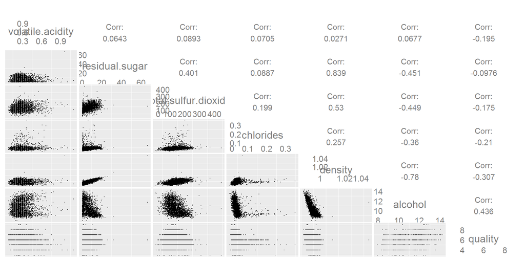

Now the second part:

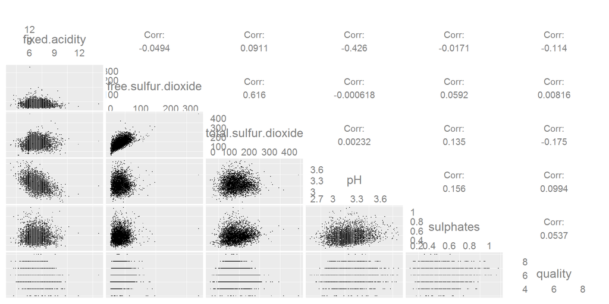

### Talk about some of the relationships you observed in this part of the investigation. How did the feature(s) of interest vary with other features in the dataset?

I didn’t notice any strong or even moderate relationship between the wine quality and other features. However I noticed: 1. weak correlation between ‘quality’ and ‘alcohol’ with the Pearson’s r of 0.4356. It means that the bigger the ‘alcohol’ value is, the higher is the wine quality mark. It doesn’t mean any causation; 2. even weaker correlation between ‘quality’ and ‘density’ with r of -0.3071. It means that the wine quality grows when ‘density’ declines. Again, no causation; 3. there are a few other slight correlations with ‘quality’: + chlorides, r = -0.21; + volatile.acidity, r = -0.195; + total.sulphur.dioxide, r = -0.175.

### Did you observe any interesting relationships between the other features (not the main feature(s) of interest)?

I observed relationship between the following variables: 1. ‘alcohol’ and ‘density’, r = -0.78. This can be explained by physics: alcohol has a lower density than water, so the more alcohol we have, the less the total density will be; 2. ‘total.sulfur.dioxide’ and ‘free.sulfur.dioxide’, r = 0.616. Based on the names, I suspect that ‘free.sulfur.dioxide’ could be a subset of ‘total.sulfur.dioxide’; 3. ‘density’ and ‘total.sulfur.dioxide’, r = 0.53;

### What was the strongest relationship you found?

The strongest relationship is seen between ‘density’ and ‘residual.sugar’, r = 0.839. This is a strong correlation indeed. It can be explained by the same physics as well.

Now let me subset only good wine and make a separate ggpairs() for it. What will I see?

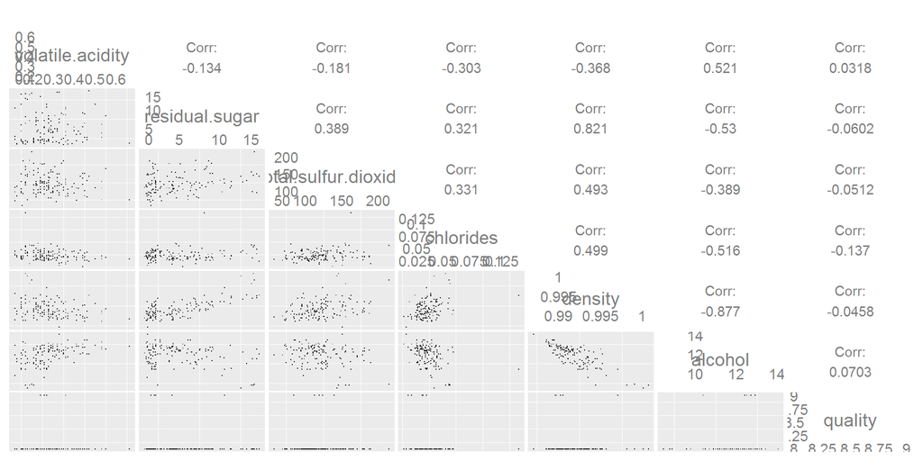

Let me have a similar look at bad wine. Again, I subset bad wine and look at relationship between all variables using ggpairs().

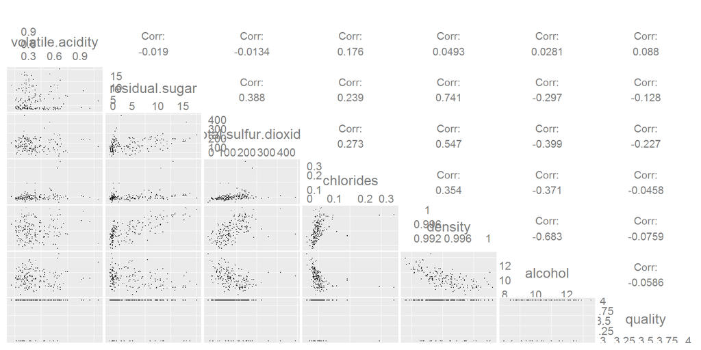

Next I took a deep look at the results of ggpairs for good wine and for bad wine. Literally I printed out two pictures, put them next to each other and studied them. Plots are still quite small at the A4 sheet, but I noticed that some plots for the same variables look differently for good wine and bad wine.

It makes me think that there might be a relationship between ‘quality’ and some combination of these variables (such as ratio, for example).

# Multivariate Plots Section

# Multivariate Analysis

Let me go through my findings one by one and see if they worth something. I will put the plots for each pair of variables next to each other split by my ‘qual’ variable (which is actually a bin). Next I’ll look at the plot of some combination of the two variables. Finally I’ll calculate Pearson’s r for the combination and ‘quality’.

### Talk about some of the relationships you observed in this part of the investigation. Were there features that strengthened each other in terms of looking at your feature(s) of interest?

Let’s start with ‘alcohol’ and ‘fixed.acidity’:

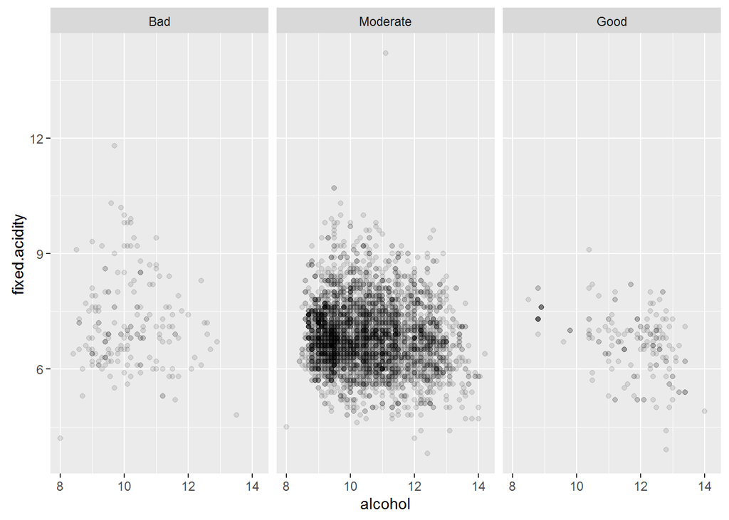

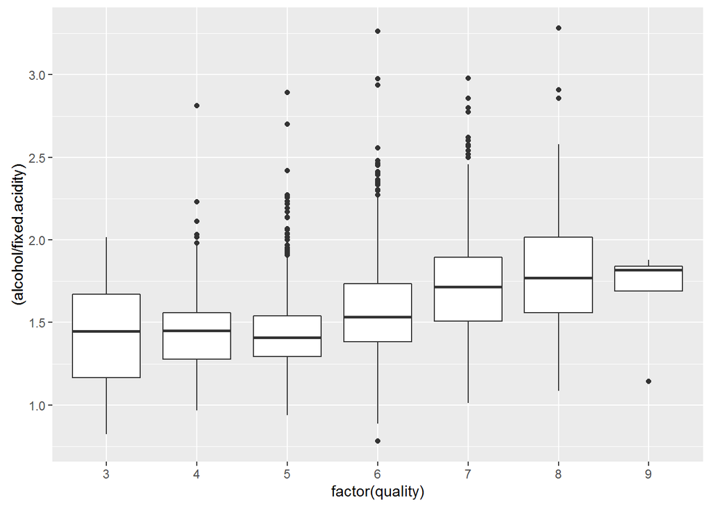

```
##
##  Pearson's product-moment correlation
##
## data:  quality and alcohol/fixed.acidity
## t = 26.693, df = 4896, p-value < 2.2e-16
## alternative hypothesis: true correlation is not equal to 0
## 95 percent confidence interval:
##  0.3317301 0.3806321
## sample estimates:
##       cor
## 0.3564252
```

Moderate wines bring a lot of noise to the comparisson.

Next I drew a box plot for ‘quality’ and the ratio of alcohol and fixed.acidity. The second picture shows that the median of the ratio grows as the wine quality does.

Next up ‘alcohol’ and ‘volatile.acidity’:

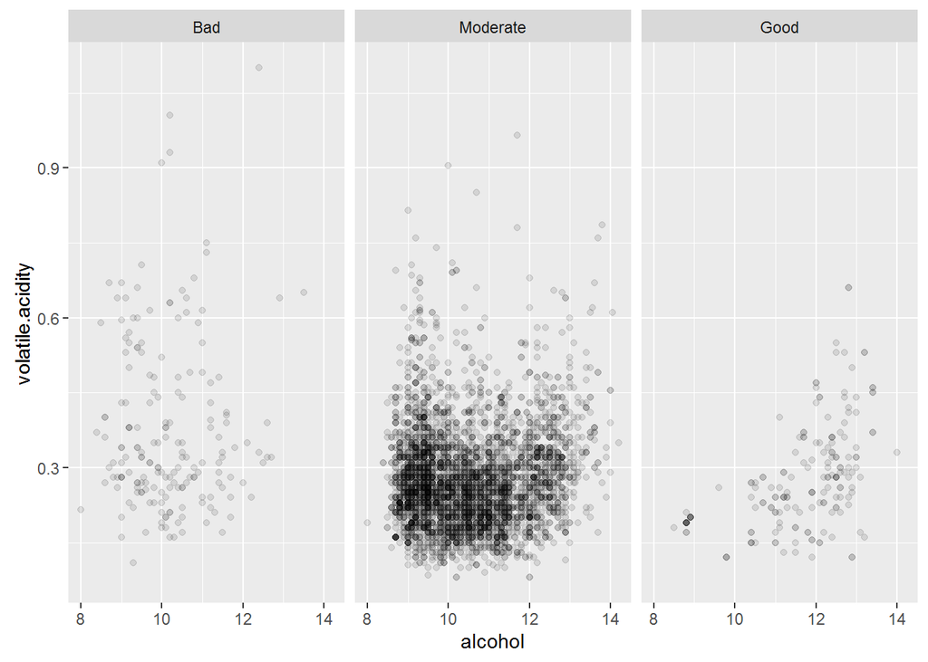

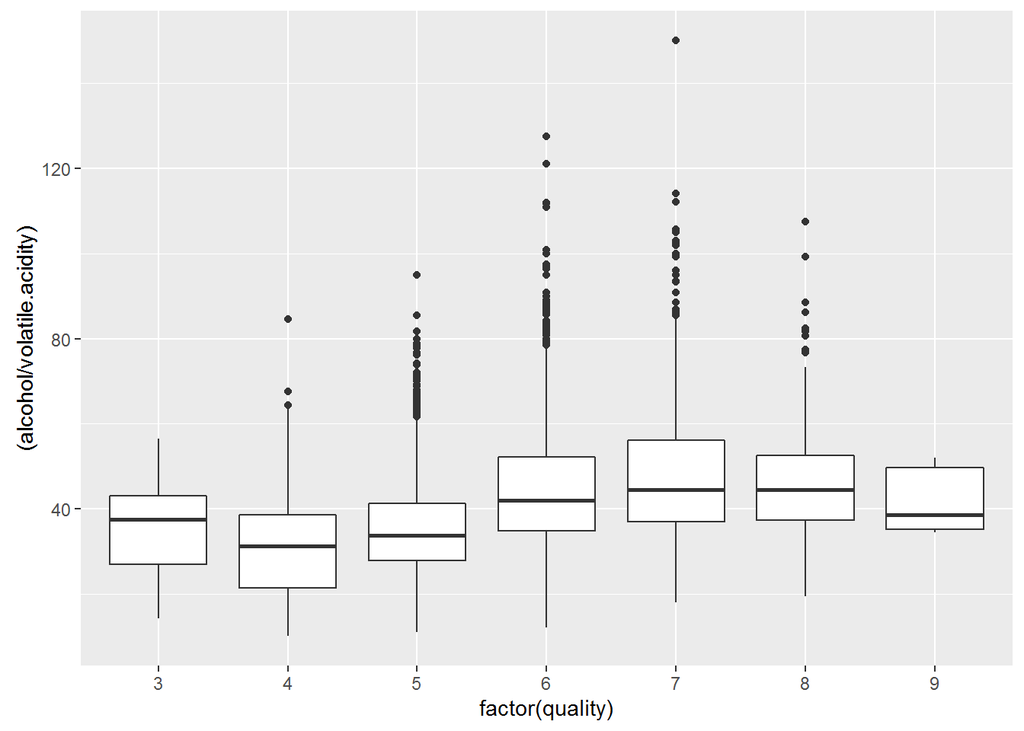

```
##
##  Pearson's product-moment correlation
##
## data:  quality and alcohol/volatile.acidity
## t = 22.259, df = 4896, p-value < 2.2e-16
## alternative hypothesis: true correlation is not equal to 0
## 95 percent confidence interval:
##  0.2774931 0.3283623
## sample estimates:
##       cor
## 0.3031436
```

Quite similar results. One could see point the centers of clusters as well. However the trend of the ratio median growth isn’t so clear. However r = 0.3031.

### Were there any interesting or surprising interactions between features?

Now ‘citric.acid’ and ‘free.sulfur.dioxide’:

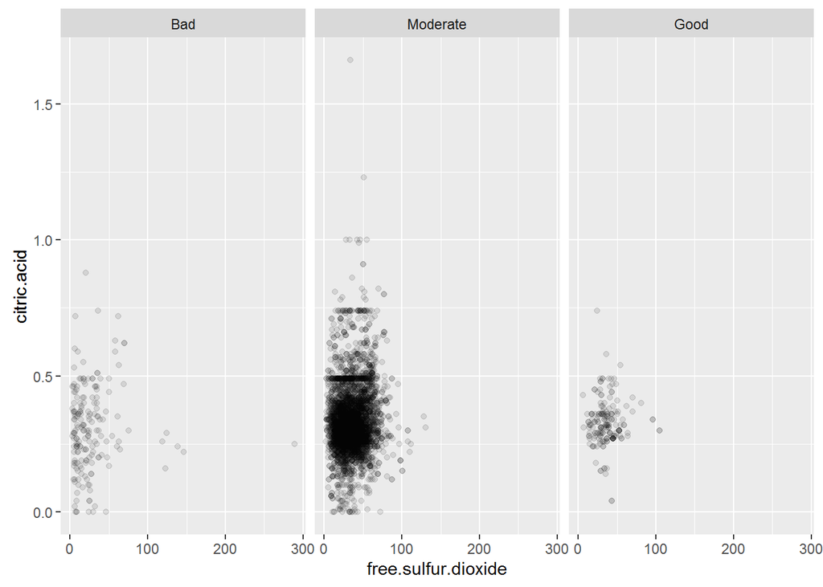

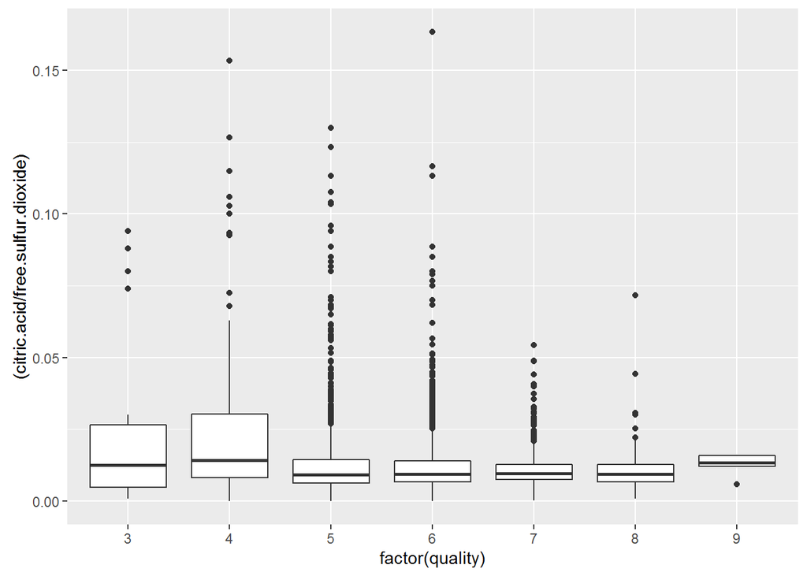

```
##
##  Pearson's product-moment correlation
##
## data:  quality and citric.acid/free.sulfur.dioxide
## t = -9.5963, df = 4896, p-value < 2.2e-16
## alternative hypothesis: true correlation is not equal to 0
## 95 percent confidence interval:
##  -0.1632586 -0.1082790
## sample estimates:
##        cor
## -0.1358734
```

This one is interesting, too. The clusters for Bad and Good are clearly different, but the ratio-based approach doesn’t work here so well: r = -0.1359. Nevertheless I see that Good wines have more free.sulfur.dioxide with less variation and more citric.acid also with less variation.

Now ‘alcohol’ and ‘chlorides’:

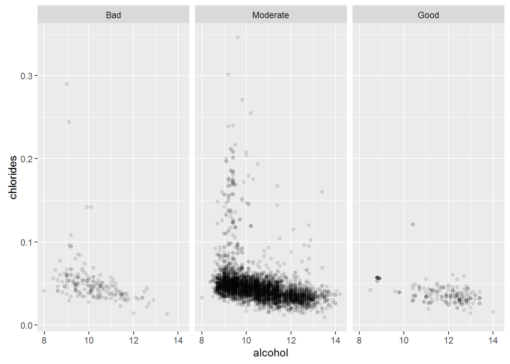

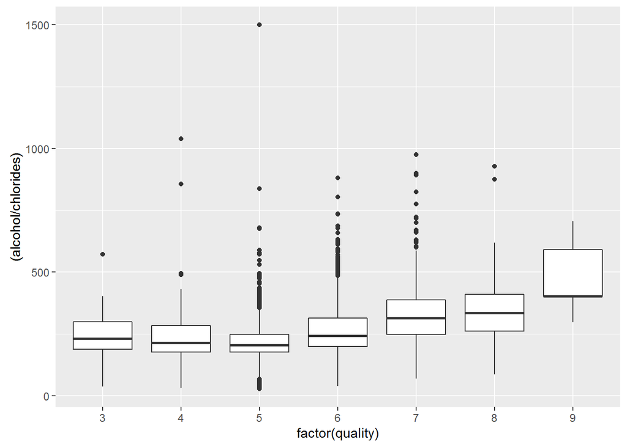

```
##
##  Pearson's product-moment correlation
##
## data:  quality and alcohol/chlorides
## t = 25.999, df = 4896, p-value < 2.2e-16
## alternative hypothesis: true correlation is not equal to 0
## 95 percent confidence interval:
##  0.3234448 0.3726675
## sample estimates:
##       cor
## 0.3482962
```

The ratio approach works here. The cluster center for Good wines is clearly on the right. In this case r = 0.3483 for the ratio and ‘quality’.

Finally ‘alcohol’ vs. ‘density’:

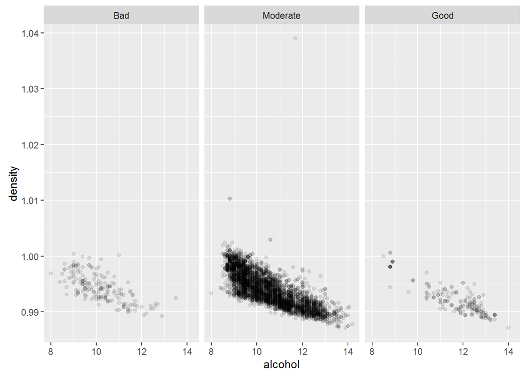

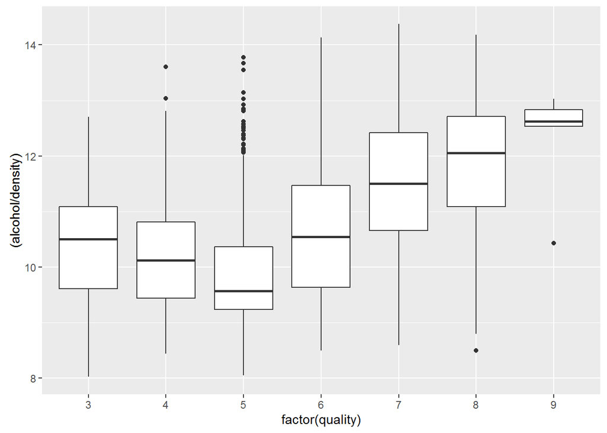

```
##
##  Pearson's product-moment correlation
##
## data:  quality and alcohol/density
## t = 33.8, df = 4896, p-value < 2.2e-16
## alternative hypothesis: true correlation is not equal to 0
## 95 percent confidence interval:
##  0.4119777 0.4574000
## sample estimates:
##       cor
## 0.4349655
```

Using the ratio again. Best r of 0.435, but still can’t be considered strong.